# Problem Statement

• DOMAIN: Industrial safety. NLP based Chatbot.

• CONTEXT:

The database comes from one of the biggest industry in Brazil and in the world. It is an urgent need for industries/companies around the globe to understand why employees still suffer some injuries/accidents in plants. Sometimes they also die in such environment.

• DATA DESCRIPTION:

This The database is basically records of accidents from 12 different plants in 03 different countries which every line in the data is an occurrence of an accident.

Columns description:

‣ **Data**: timestamp or time/date information

‣ **Countries**: which country the accident occurred (anonymised)

‣ **Local**: the city where the manufacturing plant is located (anonymised)

‣ **Industry sector**: which sector the plant belongs to

‣ **Accident level**: from I to VI, it registers how severe was the accident (I means not severe but VI means very severe)

‣ **Potential Accident Level**: Depending on the Accident Level, the database also registers how severe the accident could have been (due to other factors involved in the accident)

‣ **Genre**: if the person is male of female

‣ **Employee or Third Party**: if the injured person is an employee or a third party ‣ Critical Risk: some description of the risk involved in the accident

‣ **Description**: Detailed description of how the accident happened. Link to download the dataset: https://www.kaggle.com/ihmstefanini/industrial-safety-and-health-analytics-database [ for your reference only ]

• PROJECT OBJECTIVE: Design a ML/DL based chatbot utility which can help the professionals to highlight the safety risk as per the incident description.

## • PROJECT TASK: [ Score: 100 points]

### 1. **Milestone 1**: [ Score: 40 points ]

‣ Input: Context and Dataset ‣ Process:

‣ Step 1: Import the data [ 3 points ]

‣ Step 2: Data cleansing [ 5 points ]

‣ Step 3: Data preprocessing (NLP Preprocessing techniques) [ 7 points ]

‣ Step 4: Data preparation - Cleansed data in .xlsx or .csv file [ 5 points ]

‣ Step 5: Design train and test basic machine learning classifiers [ 10 Points ]

‣ Step 6: Interim report [ 10 points ]

‣ Submission: Interim report, Jupyter Notebook with all the steps in Milestone-1

### 2. **Milestone 2**: [ Score: 60 points ]

‣ Input: Preprocessed output from Milestone-1 ‣ Process:

‣ Step 1: Design, train and test Neural networks classifiers [ 5 points ]

‣ Step 2: Design, train and test RNN or LSTM classifiers [ 10 points ]

‣ Step 3: Choose the best performing classifier and pickle it. [ 5 points ]

‣ Step 4: Final Report [40 Points]

‣ Submission: Final report, Jupyter Notebook with all the steps in Milestone-1 and Milestone-2

### 3. **Milestone 3**: [ Optional ]

‣ Process:

‣ Step 1: Design a clickable UI based chatbot interface

‣ Submission: Final report, Jupyter Notebook with the addition of clickable UI based interface

‣ Hints:

‣ Please refer to the blog to understand the basic designing and functioning of chatbots: https://www.mygreatlearning.com/blog/basicsof-building-an-artificial-intelligence-chatbot/

‣ To make GUI as a desk app you can use TKINTER library. ‣ To make web service GUI you can use FLASK or DJANGO library

Need to install the following libraries

- CatBoost
- Optuna
- contractions

```python
!pip install wordcloud

!pip install lightgbm

!pip install catboost

!pip install optuna
```

```python
# Importing all the libraries

import numpy as np
np.random.seed(7)

import pandas as pd
import matplotlib.pyplot as plt
%matplotlib inline

import seaborn as sns

import random, re
import time
import nltk
import contractions
nltk.download('punkt') # helpful for tokenization
nltk.download('all')

from nltk.corpus import stopwords
from nltk import word_tokenize
# Used in Lemmatization
from nltk.stem import WordNetLemmatizer

import warnings
import tensorflow as tf
# Importimng ML Models
from sklearn.model_selection import GridSearchCV
from sklearn import metrics
from sklearn.metrics import accuracy_score
from sklearn.ensemble import BaggingClassifier, RandomForestClassifier
from sklearn.linear_model import LogisticRegression
from sklearn.svm import SVC
from sklearn import preprocessing
from sklearn.impute import SimpleImputer
from sklearn.tree import DecisionTreeClassifier
from sklearn.ensemble import AdaBoostClassifier
from sklearn.ensemble import GradientBoostingClassifier
```

```
WARNING:tensorflow:From C:\Users\Local User\AppData\Roaming\Python\Python311\site-packages\keras\src\losses.py:2976: The name tf.losses.sparse_softmax_cross_entropy is deprecated. Please use tf.compat.v1.losses.sparse_softmax_cross_entropy instead.
```

```python
# suppress display of warnings
warnings.filterwarnings('ignore')
# display all dataframe columns
pd.options.display.max_columns = None
# set the limit to 3 decimals
pd.options.display.float_format = '{:.7f}'.format
# display all dataframe rows
pd.options.display.max_rows = None
# display all the text inside a column
pd.set_option('max_colwidth', None)
```

#### Step 1: Import the data

```python
file_path = "./archive/IHMStefanini_industrial_safety_and_health_database_with_accidents_description.csv"
# Importing the data
industry_df = pd.read_csv(file_path)
```

```python
industry_df.shape
```

```
(425, 11)
```

```python
industry_df.info()
```

```
<class 'pandas.core.frame.DataFrame'>
RangeIndex: 425 entries, 0 to 424
Data columns (total 11 columns):
 #   Column                    Non-Null Count  Dtype
---  ------                    --------------  -----
 0   Unnamed: 0                425 non-null    int64
 1   Data                      425 non-null    object
 2   Countries                 425 non-null    object
 3   Local                     425 non-null    object
 4   Industry Sector           425 non-null    object
 5   Accident Level            425 non-null    object
 6   Potential Accident Level  425 non-null    object
 7   Genre                     425 non-null    object
 8   Employee or Third Party   425 non-null    object
 9   Critical Risk             425 non-null    object
 10  Description               425 non-null    object
dtypes: int64(1), object(10)
memory usage: 36.7+ KB
```

```python
industry_df.head(5)
```

|  | Unnamed: 0 | Data | Countries | Local | Industry Sector | Accident Level | Potential Accident Level | Genre | Employee or Third Party | Critical Risk | Description |
| --- | --- | --- | --- | --- | --- | --- | --- | --- | --- | --- | --- |
| 0 | 0 | 2016-01-01 00:00:00 | Country_01 | Local_01 | Mining | I | IV | Male | Third Party | Pressed | While removing the drill rod of the Jumbo 08 for maintenance, the supervisor proceeds to loosen the support of the intermediate centralizer to facilitate the removal, seeing this the mechanic supports… |
| 1 | 1 | 2016-01-02 00:00:00 | Country_02 | Local_02 | Mining | I | IV | Male | Employee | Pressurized Systems | During the activation of a sodium sulphide pump, the piping was uncoupled and the sulfide solution was designed in the area to reach the maid. Immediately she made use of the emergency shower and was … |
| 2 | 2 | 2016-01-06 00:00:00 | Country_01 | Local_03 | Mining | I | III | Male | Third Party (Remote) | Manual Tools | In the sub-station MILPO located at level +170 when the collaborator was doing the excavation work with a pick (hand tool), hitting a rock with the flat part of the beak, it bounces off hitting the st… |
| 3 | 3 | 2016-01-08 00:00:00 | Country_01 | Local_04 | Mining | I | I | Male | Third Party | Others | Being 9:45 am. approximately in the Nv. 1880 CX-695 OB7, the personnel begins the task of unlocking the Soquet bolts of the BHB machine, when they were in the penultimate bolt they identified that the… |
| 4 | 4 | 2016-01-10 00:00:00 | Country_01 | Local_04 | Mining | IV | IV | Male | Third Party | Others | Approximately at 11:45 a.m. in circumstances that the mechanics Anthony (group leader), Eduardo and Eric Fernández-injured-the three of the Company IMPROMEC, performed the removal of the pulley of the… |

Observations:

1. All the columns are categorical except the first column which is row serial number.
2. Data column can be renamed as "Date". It contains a dummy time stamp which is same for all the rows hence this can be removed.
3. There are 425 rows and 11 columns.
4. Column "Description" contain text data.

#### Step 2: Data cleansing

```python
# dropping column "Unnamed: 0"
industry_df.drop("Unnamed: 0", axis=1, inplace=True)
industry_df.columns
```

```
Index(['Data', 'Countries', 'Local', 'Industry Sector', 'Accident Level',
       'Potential Accident Level', 'Genre', 'Employee or Third Party',
       'Critical Risk', 'Description'],
      dtype='object')
```

```python
# Renaming 'Data', 'Countries', 'Genre', 'Employee or Third Party' columns in Data frame
industry_df.rename(columns={'Data':'Date', 'Countries':'Country', 'Genre':'Gender', 'Employee or Third Party':'Employee type'}, inplace=True)
industry_df.columns
```

```
Index(['Date', 'Country', 'Local', 'Industry Sector', 'Accident Level',
       'Potential Accident Level', 'Gender', 'Employee type', 'Critical Risk',
       'Description'],
      dtype='object')
```

```python
# Checking duplicates
industry_df.duplicated().sum()
```

```
7
```

7 duplicate records are found and these will be deleted.

```python
industry_df.drop_duplicates(inplace=True)
industry_df.shape
```

```
(418, 10)
```

```python
industry_df.describe().T
```

|  | count | unique | top | freq |
| --- | --- | --- | --- | --- |
| Date | 418 | 287 | 2017-02-08 00:00:00 | 6 |
| Country | 418 | 3 | Country_01 | 248 |
| Local | 418 | 12 | Local_03 | 89 |
| Industry Sector | 418 | 3 | Mining | 237 |
| Accident Level | 418 | 5 | I | 309 |
| Potential Accident Level | 418 | 6 | IV | 141 |
| Gender | 418 | 2 | Male | 396 |
| Employee type | 418 | 3 | Third Party | 185 |
| Critical Risk | 418 | 33 | Others | 229 |
| Description | 418 | 411 | During the activity of chuteo of ore in hopper OP5; the operator of the locomotive parks his equipment under the hopper to fill the first car, it is at this moment that when it was blowing out to rele… | 2 |

```python
# Checking unique values of all columns except 'Description' column
for x in industry_df.columns:
    if x != 'Description':
      print('--'*30); print(f'Unique values of "{x}" column'); print('--'*30)
      print(industry_df[x].unique())
      print('\n')
```

```
------------------------------------------------------------
Unique values of "Date" column
------------------------------------------------------------
['2016-01-01 00:00:00' '2016-01-02 00:00:00' '2016-01-06 00:00:00'
 '2016-01-08 00:00:00' '2016-01-10 00:00:00' '2016-01-12 00:00:00'
 '2016-01-16 00:00:00' '2016-01-17 00:00:00' '2016-01-19 00:00:00'
 '2016-01-26 00:00:00' '2016-01-28 00:00:00' '2016-01-30 00:00:00'
 '2016-02-01 00:00:00' '2016-02-02 00:00:00' '2016-02-04 00:00:00'
 '2016-02-06 00:00:00' '2016-02-07 00:00:00' '2016-02-08 00:00:00'
 '2016-02-21 00:00:00' '2016-02-25 00:00:00' '2016-02-09 00:00:00'
 '2016-02-10 00:00:00' '2016-02-15 00:00:00' '2016-02-14 00:00:00'
 '2016-02-13 00:00:00' '2016-02-16 00:00:00' '2016-02-17 00:00:00'
 '2016-02-19 00:00:00' '2016-02-20 00:00:00' '2016-02-18 00:00:00'
 '2016-02-22 00:00:00' '2016-02-24 00:00:00' '2016-02-29 00:00:00'
 '2016-02-26 00:00:00' '2016-02-27 00:00:00' '2016-03-02 00:00:00'
 '2016-03-03 00:00:00' '2016-03-04 00:00:00' '2016-03-05 00:00:00'
 '2016-03-06 00:00:00' '2016-03-09 00:00:00' '2016-03-11 00:00:00'
 '2016-03-13 00:00:00' '2016-03-12 00:00:00' '2016-03-14 00:00:00'
 '2016-03-16 00:00:00' '2016-03-10 00:00:00' '2016-03-17 00:00:00'
 '2016-03-18 00:00:00' '2016-03-19 00:00:00' '2016-03-22 00:00:00'
 '2016-03-25 00:00:00' '2016-03-30 00:00:00' '2016-03-31 00:00:00'
 '2016-04-01 00:00:00' '2016-04-03 00:00:00' '2016-04-02 00:00:00'
 '2016-03-24 00:00:00' '2016-04-04 00:00:00' '2016-04-05 00:00:00'
 '2016-04-07 00:00:00' '2016-04-08 00:00:00' '2016-04-11 00:00:00'
 '2016-04-14 00:00:00' '2016-04-16 00:00:00' '2016-04-15 00:00:00'
 '2016-04-17 00:00:00' '2016-04-18 00:00:00' '2016-04-21 00:00:00'
 '2016-04-22 00:00:00' '2016-04-23 00:00:00' '2016-04-26 00:00:00'
 '2016-04-28 00:00:00' '2016-04-29 00:00:00' '2016-04-30 00:00:00'
 '2016-05-01 00:00:00' '2016-05-02 00:00:00' '2016-05-04 00:00:00'
 '2016-05-03 00:00:00' '2016-05-05 00:00:00' '2016-05-11 00:00:00'
 '2016-05-12 00:00:00' '2016-05-14 00:00:00' '2016-05-17 00:00:00'
 '2016-05-19 00:00:00' '2016-05-18 00:00:00' '2016-05-22 00:00:00'
 '2016-05-20 00:00:00' '2016-05-24 00:00:00' '2016-05-25 00:00:00'
 '2016-05-27 00:00:00' '2016-05-26 00:00:00' '2016-06-01 00:00:00'
 '2016-06-02 00:00:00' '2016-06-03 00:00:00' '2016-06-04 00:00:00'
 '2016-06-05 00:00:00' '2016-06-08 00:00:00' '2016-06-07 00:00:00'
 '2016-06-10 00:00:00' '2016-06-13 00:00:00' '2016-06-16 00:00:00'
 '2016-06-18 00:00:00' '2016-06-17 00:00:00' '2016-06-19 00:00:00'
 '2016-06-21 00:00:00' '2016-06-22 00:00:00' '2016-06-23 00:00:00'
 '2016-06-24 00:00:00' '2016-06-29 00:00:00' '2016-07-02 00:00:00'
```

[output cut: 103 more lines]

```

------------------------------------------------------------
Unique values of "Critical Risk" column
------------------------------------------------------------
['Pressed' 'Pressurized Systems' 'Manual Tools' 'Others'
 'Fall prevention (same level)' 'Chemical substances' 'Liquid Metal'
 'Electrical installation' 'Confined space'
 'Pressurized Systems / Chemical Substances'
 'Blocking and isolation of energies' 'Suspended Loads' 'Poll' 'Cut'
 'Fall' 'Bees' 'Fall prevention' '\nNot applicable' 'Traffic' 'Projection'
 'Venomous Animals' 'Plates' 'Projection/Burning' 'remains of choco'
 'Vehicles and Mobile Equipment' 'Projection/Choco' 'Machine Protection'
 'Power lock' 'Burn' 'Projection/Manual Tools'
 'Individual protection equipment' 'Electrical Shock'
 'Projection of fragments']
```

Observations:

1. Date ranges from 2016-01-01 to 2017-07-09. So there is no outliers in this attribute.
2. there are 3 countries(masked).
3. local has 12 variants(masked).
4. 3 industry sectors, namely 'Mining' 'Metals' 'Others'.
5. there are 5 accident level ranging from 1 to 5.
6. there are 6 potential accident levels ranging from 1 to 6.
7. 2 genders. 'Male' 'Female'
8. 3 types of employee working in plant; 'Third Party' 'Employee' 'Third Party (Remote)'.
9. There are manay critical risk.

```python
# Checking the missing values
industry_df.isnull().sum()
```

```
Date                        0
Country                     0
Local                       0
Industry Sector             0
Accident Level              0
Potential Accident Level    0
Gender                      0
Employee type               0
Critical Risk               0
Description                 0
dtype: int64
```

Observations: There are no missing values in the dataframe.

Summary:

1. Removed 'Unnamed: 0' column and renamed - 'Data', 'Countries', 'Genre', 'Employee or Third Party' columns in the dataset.
2. We had 7 duplicate instances in the dataset and dropped those duplicates.
3. There are no outliers in the dataset.
4. No missing values in dataset.
5. We are left with 418 rows and 10 columns after data cleansing.

### EDA

```
--------------------------------------------------------------------------------------------------------------
Checking 5 random Descriptions and accident_levels from the data where the length of Description is > 100
--------------------------------------------------------------------------------------------------------------
Description: In the support process, in circumstances that the assistant performs the Last cut in the transverse length of the mesh; The mesh generates a movement towards the operator and hits the face causing the described injury.
accident_level: I

Description: When it opens the suction valve of the 420-BO-01 acid pump, the cable of the same pump comes loose by pressing the 5th finger of the employee's left hand against the tubing, causing a fracture in the distal phalanx. Photos
accident_level: III

Description: On pit 831 of level 1910 when radial drilling was performed of negative holes with the simba M4C ITH No. 5 equipment, when the assistant of the equipment operator made the change of the drill bit, the metal bar (hammer) is released from the coupling of the rotation unit and when abruptl…
accident_level: I

Description: After the welder completed the welding work to reinforce the forms in the deepening, he walked towards the distant truck at about 40 mt, at which point the welder stepped on a fragment of rock of 5 cm x 10cm x 5cm approx. which generates that the foot flexes and generates the injury in …
accident_level: I

Description: The technician was doing the magnetometric survey when he stepped on a thorn. His reaction was to immediately retreat, losing his balance and so the magnetometer's antenna broke.
accident_level: I

--------------------------------------------------------------------------------
Distributon of accident_level where the length of Description is > 100
--------------------------------------------------------------------------------
```

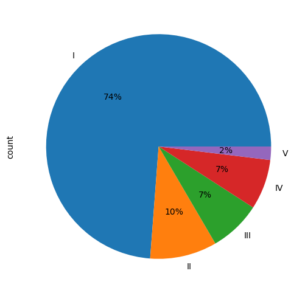

```python
# Checking 5 random Descriptions and Accident Level from the data where the length of headline is > 100

print('--'*55); print('Checking 5 random Descriptions and accident_levels from the data where the length of Description is > 100'); print('--'*55)

# getting the indexes where the length of the description is greater than 100.
indexes = list(industry_df.loc[industry_df['Description'].str.len() > 100, 'Description'].index)
rands = random.sample(indexes, 5)
descriptions, accident_levels = list(industry_df.loc[rands, 'Description']), list(industry_df.loc[rands, 'Accident Level'])

_ = [print(f'Description: {description}\naccident_level: {acclevel}\n') for description, acclevel in zip(descriptions, accident_levels)]

print('--'*40); print('Distributon of accident_level where the length of Description is > 100'); print('--'*40)
_ = industry_df.loc[indexes, 'Accident Level'].value_counts().plot(kind = 'pie', autopct = '%.0f%%', labels = ['I', 'II', 'III', 'IV', 'V'], figsize = (10, 6))
```

Observations:

1. 74% of data where accident description > 100 is captured in low accident level.
2. The number of accidents where description > 100 are decreasing when the accident levels are increasing.
3. there are date and time mentioned in the description which are essential.

```
------------------------------------------------------------------------------------------------------------------------
Checking 5 random Descriptions and pot_accident_levels from the data where the length of Description is > 100
------------------------------------------------------------------------------------------------------------------------
Description: During the withdrawal of the fixed jaw wedge from the crusher 41BR01, the hoisting device (hook) was broken causing the steel cable of the overhead crane to strike the left hand of the employee.
pot_accident_level: IV

Description: The maid was handling a pipette for sample preparation for chemical analysis, while trying to place it on the three-way pear, the pipette came to break causing a superficial cut in her right hand.
pot_accident_level: III

Description: at level 2900, during the ore hauling activity with locomotive from the OP2 to the bines, at times when the convoy was traveling through the hopper of the OP1, the assistant motorist who was riding in the saddle holding the pole is struck weakly by a split set which was suspended in the…
pot_accident_level: III

Description: At times that the workers: Technician and Mr. Orlando of Boltec 2 of Cia. wanted to pass the hand stacker by a sardinel, the technician pulled the hydraulic arm, while Mr. was pushing from the nail of the equipment, when reaching the trench the rim is tied and the team turns forward fal…
pot_accident_level: III

Description: In circumstance, the AHK-903 license plate (Empresa which serves the supervision of CMA, carried out the field inspections in the upper bank 4288, when unexpectedly when climbing through the operational access (positive ramp), It slides in an excavated area of approximately 3 meters hig…
pot_accident_level: IV

--------------------------------------------------------------------------------
Distributon of pot_accident_level where the length of Description is > 100
--------------------------------------------------------------------------------
```

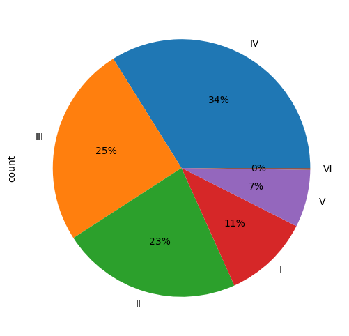

```python
# Checking 5 random Descriptions and Potential Accident Level from the data where the length of headline is > 100
print('--'*60); print('Checking 5 random Descriptions and pot_accident_levels from the data where the length of Description is > 100'); print('--'*60)

indexes = list(industry_df.loc[industry_df['Description'].str.len() > 100, 'Description'].index)
rands = random.sample(indexes, 5)
descriptions, pot_accident_levels = list(industry_df.loc[rands, 'Description']), list(industry_df.loc[rands, 'Potential Accident Level'])

_ = [print(f'Description: {descriptin}\npot_accident_level: {pot_acclevel}\n') for descriptin, pot_acclevel in zip(descriptions, pot_accident_levels)]

print('--'*40); print('Distributon of pot_accident_level where the length of Description is > 100'); print('--'*40)
_ = industry_df.loc[indexes, 'Potential Accident Level'].value_counts().plot(kind = 'pie', autopct = '%.0f%%', labels = ['IV', 'III', 'II', 'I', 'V', 'VI'], figsize = (10, 6))
```

Observation:

1. The tentative occurring of the incidents serverity wise;

   I - 11%

   II - 23%

   III - 25%

   IV - 34%

   V - 7%

   VI - 0%
1. The highest possibility of occurring of any incident is of type IV and then III and II subsequently.

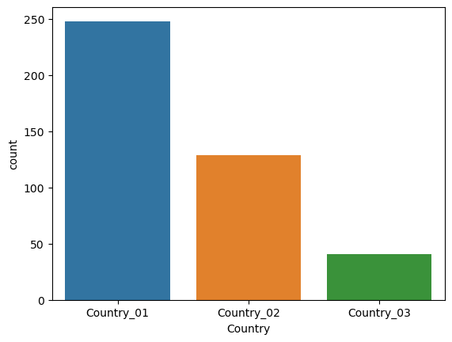

```python
sns.countplot(x=industry_df['Country'])
```

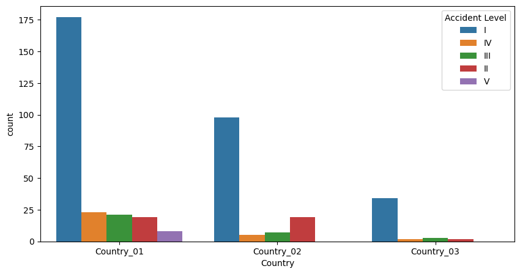

```python
plt.figure(figsize=(10, 5))
sns.countplot(x=industry_df['Country'],hue=industry_df['Accident Level'])
```

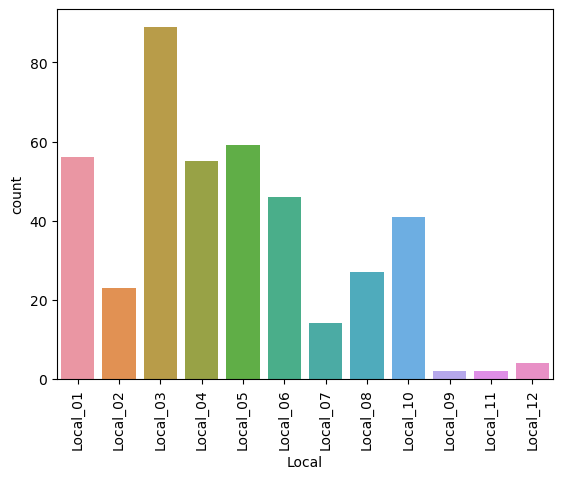

```python
sns.countplot(x=industry_df['Local'])
plt.xticks(rotation=90);
```

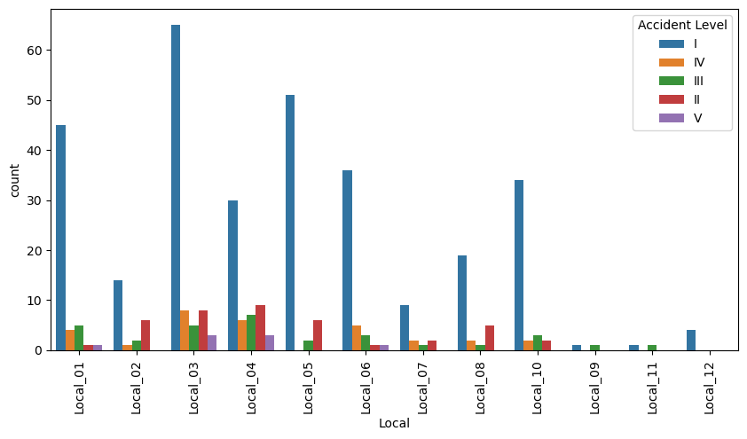

```python
plt.figure(figsize=(10, 5))
sns.countplot(x=industry_df['Local'],hue=industry_df['Accident Level'])
plt.xticks(rotation=90);
```

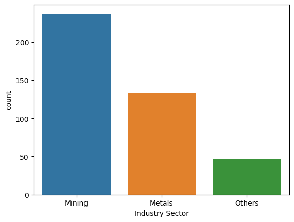

```python
sns.countplot(x=industry_df['Industry Sector'])
```

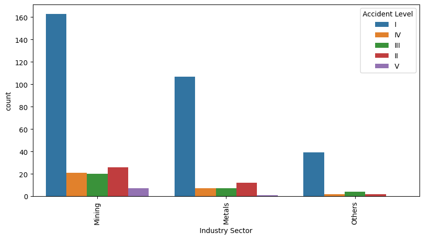

```python
plt.figure(figsize=(10, 5))
sns.countplot(x=industry_df['Industry Sector'],hue=industry_df['Accident Level'])
plt.xticks(rotation=90);
```

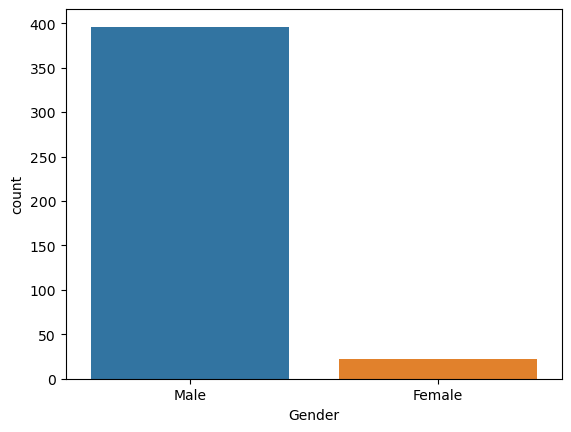

```python
sns.countplot(x=industry_df['Gender'])
```

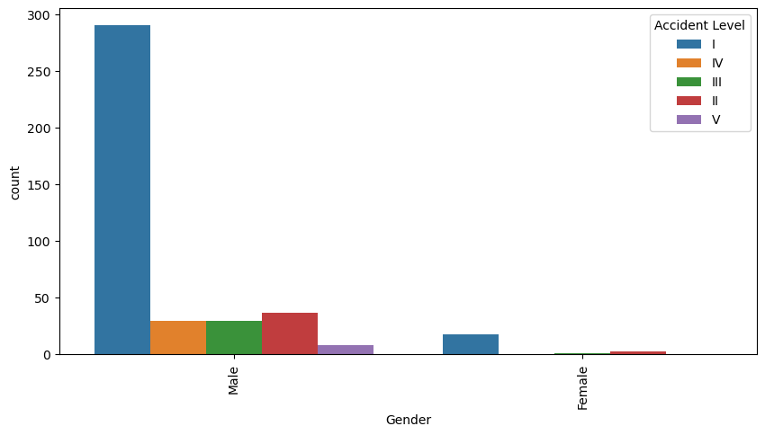

```python
plt.figure(figsize=(10, 5))
sns.countplot(x=industry_df['Gender'],hue=industry_df['Accident Level'])
plt.xticks(rotation=90);
```

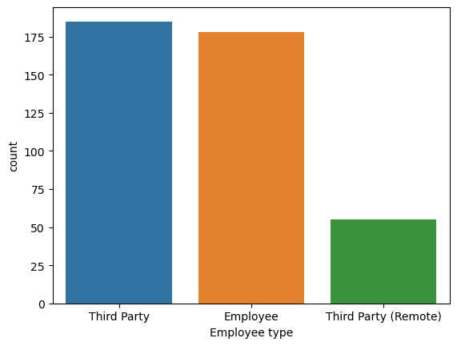

```python
sns.countplot(x=industry_df['Employee type'])
```

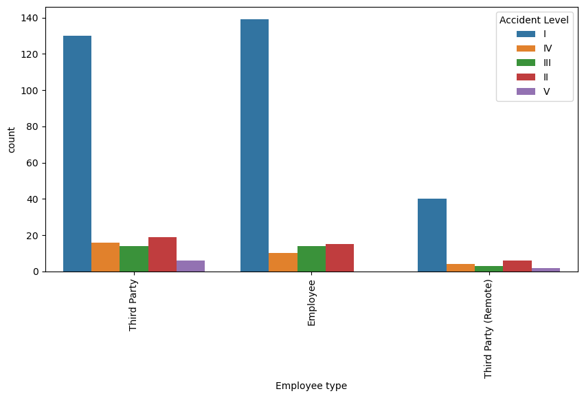

```python
plt.figure(figsize=(10, 5))
sns.countplot(x=industry_df['Employee type'],hue=industry_df['Accident Level'])
plt.xticks(rotation=90);
```

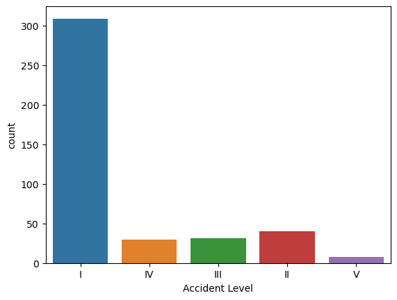

```python
sns.countplot(x=industry_df['Accident Level'])
```

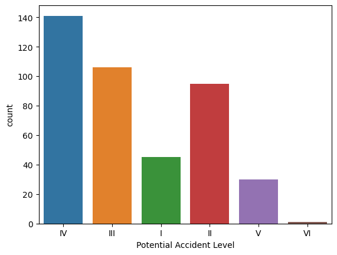

```python
sns.countplot(x=industry_df['Potential Accident Level'])
```

```python
# Defining function to clean 'Description'
def clean_text(df, punctuations=r'''!()-[]{};:'"\,<>./?@#$%^&*_~'''):
    """ A method to clean text"""
    # Cleaning the urls
    string = re.sub(r'https?://\S+|www\.\S+', '', df)
    # Cleaning the html elements
    string = re.sub(r'<.*?>', '', df)
    # Removing the punctuations using regular expression    # i.e remove anything which is not word or whitespace character
    string = re.sub(r'[^\w\s]', '', df)
    # Converting the text to lower
    string = string.lower()
    # Removing stop words
    string = ' '.join([word for word in string.split() if word not in stopwords.words('english')])
    # Cleaning the whitespaces
    string = re.sub(r'\s+', ' ', string).strip()
    #tokenize data
    string = word_tokenize(string)
    #remove number
    string=[s for s in string if s.isalpha()]
    #lemmatize the data
    string= [WordNetLemmatizer().lemmatize(i) for i in string]
    #fix contractions (example: "'cause": "because","could've": "could have",etc)
    string = ' '.join([contractions.fix(word) for word in string])
    return string
    #return " ".join(string)
```

```python
industry_df["Description"] = industry_df["Description"].astype(str)
industry_df['Cleaned_Description'] = industry_df['Description'].apply(clean_text)

industry_df.tail()
```

|  | Date | Country | Local | Industry Sector | Accident Level | Potential Accident Level | Gender | Employee type | Critical Risk | Description | Cleaned_Description |
| --- | --- | --- | --- | --- | --- | --- | --- | --- | --- | --- | --- |
| 420 | 2017-07-04 00:00:00 | Country_01 | Local_04 | Mining | I | III | Male | Third Party | Others | Being approximately 5:00 a.m. approximately, when lifting the Kelly HQ towards the pulley of the frame to align it, the assistant Marco that is in the later one is struck the hand against the frame ge… | approximately approximately lifting kelly hq towards pulley frame align assistant marco later one struck hand frame generating injury |
| 421 | 2017-07-04 00:00:00 | Country_01 | Local_03 | Mining | I | II | Female | Employee | Others | The collaborator moved from the infrastructure office (Julio to the toilets, when the pin of the right shoe is hooked on the bra of the left shoe causing not to take the step and fall untimely, causin… | collaborator moved infrastructure office julio toilet pin right shoe hooked bra left shoe causing take step fall untimely causing injury described |
| 422 | 2017-07-05 00:00:00 | Country_02 | Local_09 | Metals | I | II | Male | Employee | Venomous Animals | During the environmental monitoring activity in the area, the employee was surprised by a swarming swarm of weevils. During the exit of the place, endured suffering two stings, being one in the face a… | environmental monitoring activity area employee surprised swarming swarm weevil exit place endured suffering two sting one face middle finger left hand |
| 423 | 2017-07-06 00:00:00 | Country_02 | Local_05 | Metals | I | II | Male | Employee | Cut | The Employee performed the activity of stripping cathodes, when pulling the cathode sheet his hand hit the side of another cathode, causing a blunt cut on his 2nd finger of the left hand. | employee performed activity stripping cathode pulling cathode sheet hand hit side another cathode causing blunt cut finger left hand |
| 424 | 2017-07-09 00:00:00 | Country_01 | Local_04 | Mining | I | II | Female | Third Party | Fall prevention (same level) | At 10:00 a.m., when the assistant cleaned the floor of module "E" in the central camp, she slipped back and immediately grabbed the laundry table to avoid falling to the floor; suffering the described… | assistant cleaned floor module e central camp slipped back immediately grabbed laundry table avoid falling floor suffering described injury |

#### wordclouds

```
There are 153160 words in the combination of all texts.
```

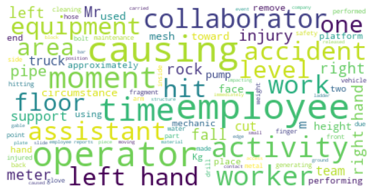

```python
from wordcloud import WordCloud, STOPWORDS, ImageColorGenerator

# wordcloud for uncleaned description texts
all_texts = " ".join(texts for texts in industry_df.Description)
print ("There are {} words in the combination of all texts.".format(len(all_texts)))

# lower max_font_size, change the maximum number of word and lighten the background:
wordcloud = WordCloud(max_font_size = 40, max_words=100, background_color="white").generate(all_texts)
plt.figure(figsize=(8,12))
plt.imshow(wordcloud)
plt.axis("off")
plt.show()
```

```
There are 96562 words in the combination of all texts.
```

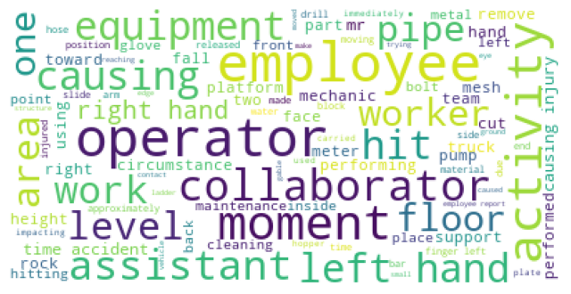

```python
# wordcloud for cleaned description texts
all_texts = " ".join(texts for texts in industry_df.Cleaned_Description)
print ("There are {} words in the combination of all texts.".format(len(all_texts)))

# lower max_font_size, change the maximum number of word and lighten the background:
wordcloud = WordCloud(max_font_size = 40, max_words=100, background_color="white").generate(all_texts)
plt.figure(figsize=(8,12))
plt.imshow(wordcloud)
plt.axis("off")
plt.show()
```

```python
#### finding the length of each line, find the maximum length and print the maximum length line

# Getting length of each line
industry_df['line_length'] = industry_df['Cleaned_Description'].str.len()

print('Minimum line length: {}'.format(industry_df['line_length'].min()))
print('Maximum line length: {}'.format(industry_df['line_length'].max()))
print('Line with maximum length: {}'.format(industry_df[industry_df['line_length'] == industry_df['line_length'].max()]['Cleaned_Description'].values[0]))
```

```
Minimum line length: 61
Maximum line length: 647
Line with maximum length: level gallery holding activity bolter equipment operator performs drilling first hole support right gable drill end drill rod break leaving thread inside drilling machine shank operator assistant decide make two empty percussion attempt free thread shank without success thi…
```

```python
#### finding the number of words, find the maximum number of words and print the maximum number of words

# getting length of each line
industry_df['nb_words'] = industry_df['Cleaned_Description'].apply(lambda x: len(x.split(' ')))

print('Minimum number of words: {}'.format(industry_df['nb_words'].min()))
print('Maximum number of words: {}'.format(industry_df['nb_words'].max()))
print('Line with maximum number of words: {}'.format(industry_df[industry_df['nb_words'] == industry_df['nb_words'].max()]['Cleaned_Description'].values[0]))
```

```
Minimum number of words: 9
Maximum number of words: 93
Line with maximum number of words: performing sleeve removal maneuver hole meter deep general da silva pressed one side locking nut rod together jack hold entire weight rod maneuver locking procedure effective weight rod secured steel wire rope probe winch moment driller pedro released brake winch i…
```

#### Step 3: Data preprocessing (NLP Preprocessing techniques)

Did text preprocessing and created a vanilla model with lightgbm algorithm.

```python
from lightgbm import LGBMClassifier
from sklearn.feature_extraction.text import CountVectorizer,TfidfVectorizer
from sklearn.preprocessing import LabelEncoder
from sklearn.model_selection import train_test_split
from sklearn.metrics import f1_score
```

```python
accident_levels = industry_df['Potential Accident Level']
label_encoder = LabelEncoder()
encoded_levels = label_encoder.fit_transform(accident_levels)
industry_df['Potential Accident Level Encoded'] = encoded_levels
```

```python
industry_df.head()
```

|  | Date | Country | Local | Industry Sector | Accident Level | Potential Accident Level | Gender | Employee type | Critical Risk | Description | Cleaned_Description | line_length | nb_words | Potential Accident Level Encoded |
| --- | --- | --- | --- | --- | --- | --- | --- | --- | --- | --- | --- | --- | --- | --- |
| 0 | 2016-01-01 00:00:00 | Country_01 | Local_01 | Mining | I | IV | Male | Third Party | Pressed | While removing the drill rod of the Jumbo 08 for maintenance, the supervisor proceeds to loosen the support of the intermediate centralizer to facilitate the removal, seeing this the mechanic supports… | removing drill rod jumbo maintenance supervisor proceeds loosen support intermediate centralizer facilitate removal seeing mechanic support one end drill equipment pull hand bar accelerate removal mom… | 276 | 37 | 3 |
| 1 | 2016-01-02 00:00:00 | Country_02 | Local_02 | Mining | I | IV | Male | Employee | Pressurized Systems | During the activation of a sodium sulphide pump, the piping was uncoupled and the sulfide solution was designed in the area to reach the maid. Immediately she made use of the emergency shower and was … | activation sodium sulphide pump piping uncoupled sulfide solution designed area reach maid immediately made use emergency shower directed ambulatory doctor later hospital note sulphide solution gram l… | 204 | 27 | 3 |
| 2 | 2016-01-06 00:00:00 | Country_01 | Local_03 | Mining | I | III | Male | Third Party (Remote) | Manual Tools | In the sub-station MILPO located at level +170 when the collaborator was doing the excavation work with a pick (hand tool), hitting a rock with the flat part of the beak, it bounces off hitting the st… | substation milpo located level collaborator excavation work pick hand tool hitting rock flat part beak bounce hitting steel tip safety shoe metatarsal area left foot collaborator causing injury | 193 | 28 | 2 |
| 3 | 2016-01-08 00:00:00 | Country_01 | Local_04 | Mining | I | I | Male | Third Party | Others | Being 9:45 am. approximately in the Nv. 1880 CX-695 OB7, the personnel begins the task of unlocking the Soquet bolts of the BHB machine, when they were in the penultimate bolt they identified that the… | approximately nv personnel begin task unlocking soquet bolt bhb machine penultimate bolt identified hexagonal head worn proceeding mr cristóbal auxiliary assistant climb platform exert pressure hand d… | 343 | 47 | 0 |
| 4 | 2016-01-10 00:00:00 | Country_01 | Local_04 | Mining | IV | IV | Male | Third Party | Others | Approximately at 11:45 a.m. in circumstances that the mechanics Anthony (group leader), Eduardo and Eric Fernández-injured-the three of the Company IMPROMEC, performed the removal of the pulley of the… | approximately circumstance mechanic anthony group leader eduardo eric fernándezinjuredthe three company impromec performed removal pulley motor pump zaf marcy cm length cm weight kg locked proceed hea… | 302 | 42 | 3 |

```python
## this snippet of code will vectorize the description
## using TFID vectorizer
dataset_final = industry_df[['Cleaned_Description', 'Potential Accident Level Encoded']]
cv = TfidfVectorizer(max_features = 1000)
vectors = cv.fit_transform(dataset_final['Cleaned_Description']).toarray()
```

#### Step 4: Data preparation - Cleansed data in .xlsx or .csv file

```python
output_file_path = './archive/CleanedData.csv'
industry_df.to_csv(output_file_path)
```

```python
# this part is the usual model building
X = vectors
y = dataset_final["Potential Accident Level Encoded"]
```

```python
X_train, X_test, y_train, y_test = train_test_split(X, y,  test_size = 0.2, random_state = 42)
```

# Using Basic ML models

```python
##  Function to calculate different metric scores of the model - Accuracy, Recall and Precision
def get_metrics_score(model,flag=True):
    ''' model : classifier to predict values of X'''
    # defining an empty list to store train and test results
    score_list=[]
    #Predicting on train and tests
    pred_train = model.predict(X_train)
    pred_test = model.predict(X_test)
    #Accuracy of the model
    train_acc = model.score(X_train,y_train)
    test_acc = model.score(X_test,y_test)
    #Recall of the model
    train_recall = metrics.recall_score(y_train,pred_train,average='micro')
    test_recall = metrics.recall_score(y_test,pred_test,average='micro')
    #Precision of the model
    train_precision = metrics.precision_score(y_train,pred_train,average='micro')
    test_precision = metrics.precision_score(y_test,pred_test,average='micro')
    # F1-Score
    train_f1 = 2*(( train_precision * train_recall ) / ( train_precision + train_recall ))
    test_f1 = 2*(( test_precision * test_recall ) / ( test_precision + test_recall ))
    score_list.extend((train_acc,test_acc,train_recall,test_recall,train_precision,test_precision,train_f1,test_f1))
    # If the flag is set to True then only the following print statements will be dispayed. The default value is set to True.
    if flag == True:
        print("Accuracy on training set : ",train_acc)
        print("Accuracy on test set : ",test_acc)
        print("Recall on training set : ",train_recall)
        print("Recall on test set : ",test_recall)
        print("Precision on training set : ",train_precision)
        print("Precision on test set : ",test_precision)
        print("f1 on training set : ",train_f1)
        print("f1 on test set : ",test_f1)
    return score_list # returning the list with train and test scores
```

```python
#Creating Confusion matrix
from sklearn.metrics import confusion_matrix
import seaborn as sns
import matplotlib.pyplot as plt

def plot_confusion_matrix(y_true, y_pred, title='Confusion Matrix', class_names=['I', 'IV', 'III', 'II', 'V']):

    # Compute confusion matrix
    conf_matrix = confusion_matrix(y_true, y_pred)

    # Plot the confusion matrix
    plt.figure(figsize=(8, 6))
    sns.heatmap(conf_matrix, annot=True, fmt='g', cmap='Blues', xticklabels=class_names, yticklabels=class_names)
    plt.xlabel('Predicted labels')
    plt.ylabel('True labels')
    plt.title(title)
    plt.show()
```

```
Accuracy on training set :  1.0
Accuracy on test set :  0.42857142857142855
Recall on training set :  1.0
Recall on test set :  0.42857142857142855
Precision on training set :  1.0
Precision on test set :  0.42857142857142855
f1 on training set :  1.0
f1 on test set :  0.42857142857142855
```

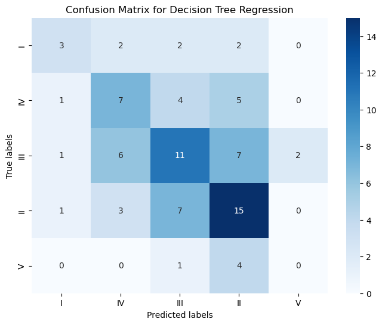

```python
#Decision Tree
dTree = DecisionTreeClassifier(criterion = 'gini', random_state=1)
dTree.fit(X_train, y_train)
dTree_score=get_metrics_score(dTree)
y_pred=dTree.predict(X_test)
plot_confusion_matrix(y_test, y_pred, title='Confusion Matrix for Decision Tree Regression')
```

```
Accuracy on training set :  0.7694610778443114
Accuracy on test set :  0.42857142857142855
Recall on training set :  0.7694610778443114
Recall on test set :  0.42857142857142855
Precision on training set :  0.7694610778443114
Precision on test set :  0.42857142857142855
f1 on training set :  0.7694610778443114
f1 on test set :  0.42857142857142855
```

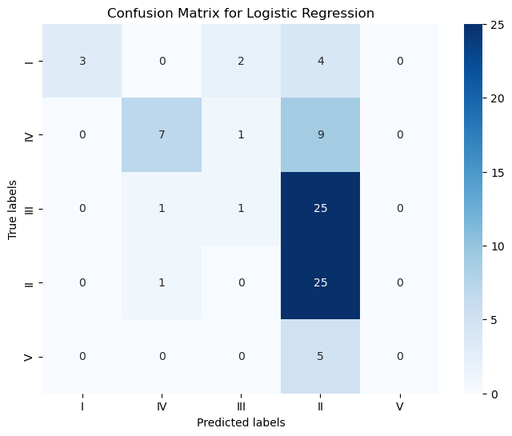

```python
#Using  Logistic Regression
logreg = LogisticRegression(solver = 'liblinear', multi_class= 'auto')
logreg.fit(X_train, y_train)
logreg_score=get_metrics_score(logreg)
y_pred=logreg.predict(X_test)
plot_confusion_matrix(y_test, y_pred, title='Confusion Matrix for Logistic Regression')
```

```
Accuracy on training set :  0.9820359281437125
Accuracy on test set :  0.39285714285714285
Recall on training set :  0.9820359281437125
Recall on test set :  0.39285714285714285
Precision on training set :  0.9820359281437125
Precision on test set :  0.39285714285714285
f1 on training set :  0.9820359281437125
f1 on test set :  0.39285714285714285
```

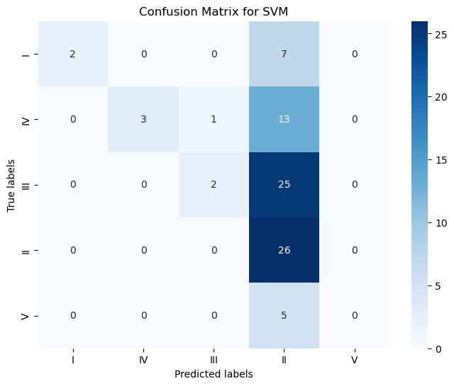

```python
#Using SVM
SVM_Classifier = SVC()
SVM_Classifier.fit(X_train,y_train)
SVM_Classifier_score=get_metrics_score(SVM_Classifier)
y_pred=SVM_Classifier.predict(X_test)
plot_confusion_matrix(y_test, y_pred, title='Confusion Matrix for SVM')
```

```python
#Random Forest
#Train the random forest classifier
rf_estimator=RandomForestClassifier(random_state=1)
rf_estimator.fit(X_train,y_train)
```

```
RandomForestClassifier(random_state=1)
```

```
Accuracy on training set :  1.0
Accuracy on test set :  0.4880952380952381
Recall on training set :  1.0
Recall on test set :  0.4880952380952381
Precision on training set :  1.0
Precision on test set :  0.4880952380952381
f1 on training set :  1.0
f1 on test set :  0.4880952380952381
```

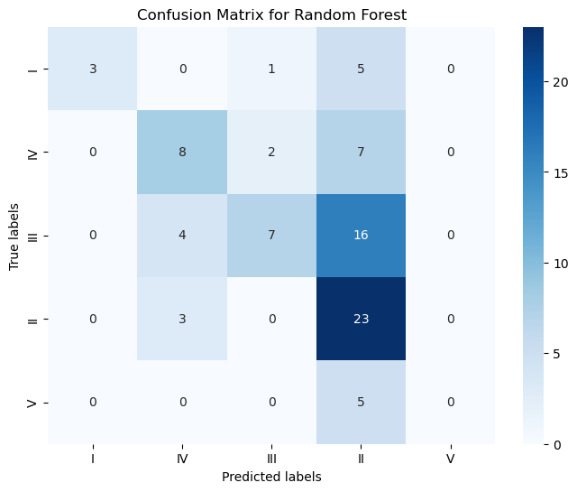

```python
#Using above defined function to get accuracy, recall and precision on train and test set
rf_estimator_score=get_metrics_score(rf_estimator)
y_pred=rf_estimator.predict(X_test)
plot_confusion_matrix(y_test, y_pred, title='Confusion Matrix for Random Forest')
```

```
Accuracy on training set :  0.4550898203592814
Accuracy on test set :  0.2857142857142857
Recall on training set :  0.4550898203592814
Recall on test set :  0.2857142857142857
Precision on training set :  0.4550898203592814
Precision on test set :  0.2857142857142857
f1 on training set :  0.4550898203592814
f1 on test set :  0.2857142857142857
```

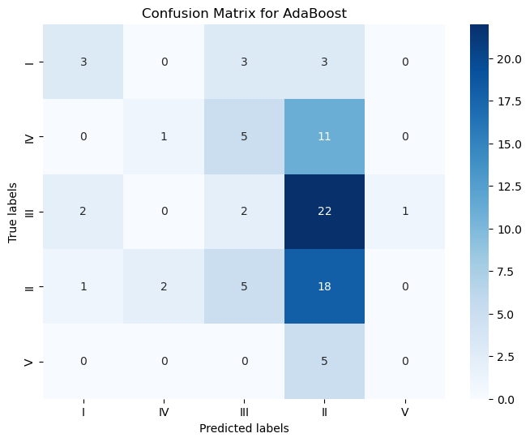

```python
# Create adaboost classifer object
abc = AdaBoostClassifier(n_estimators=50, learning_rate=1)
# Train Adaboost Classifer
abc.fit(X_train, y_train)
#Using above defined function to get accuracy, recall and precision on train and test set
abc_estimator_score=get_metrics_score(abc)
y_pred=abc.predict(X_test)
plot_confusion_matrix(y_test, y_pred, title='Confusion Matrix for AdaBoost')
```

```
Accuracy on training set :  1.0
Accuracy on test set :  0.4642857142857143
Recall on training set :  1.0
Recall on test set :  0.4642857142857143
Precision on training set :  1.0
Precision on test set :  0.4642857142857143
f1 on training set :  1.0
f1 on test set :  0.4642857142857143
```

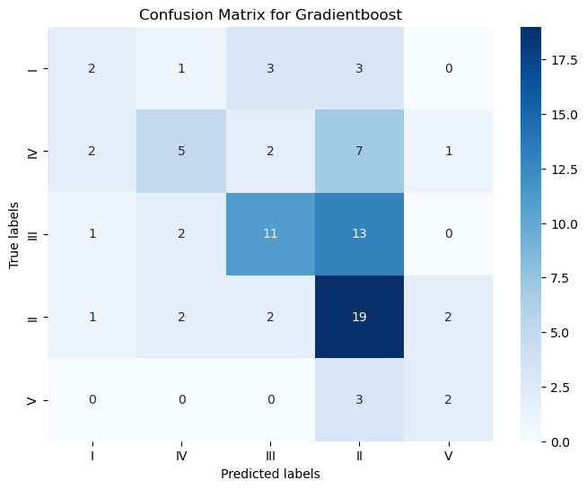

```python
# Create Gradientboost classifer object
gbclf = GradientBoostingClassifier(n_estimators=100, learning_rate=1.0, max_depth=3, random_state=0)
gbclf.fit(X_train, y_train)

#Using above defined function to get accuracy, recall and precision on train and test set
gbclf_score=get_metrics_score(gbclf)
y_pred=gbclf.predict(X_test)
plot_confusion_matrix(y_test, y_pred, title='Confusion Matrix for Gradientboost')
```

```
Accuracy on training set :  1.0
Accuracy on test set :  0.47619047619047616
Recall on training set :  1.0
Recall on test set :  0.47619047619047616
Precision on training set :  1.0
Precision on test set :  0.47619047619047616
f1 on training set :  1.0
f1 on test set :  0.47619047619047616
```

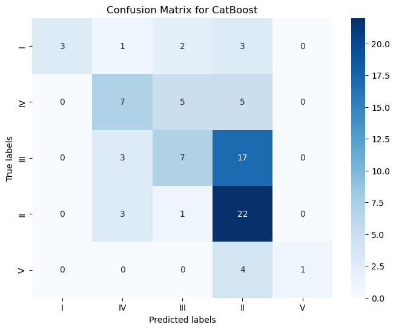

```python
#using CatBoost
from catboost import CatBoostClassifier
mCat = CatBoostClassifier(verbose=0)
mCat.fit(X_train, y_train)
mCat_score=get_metrics_score(mCat)
y_pred=mCat.predict(X_test)
plot_confusion_matrix(y_test, y_pred, title='Confusion Matrix for CatBoost')
```

[output not shown]

[output cut: 553 more lines]

[output not shown]

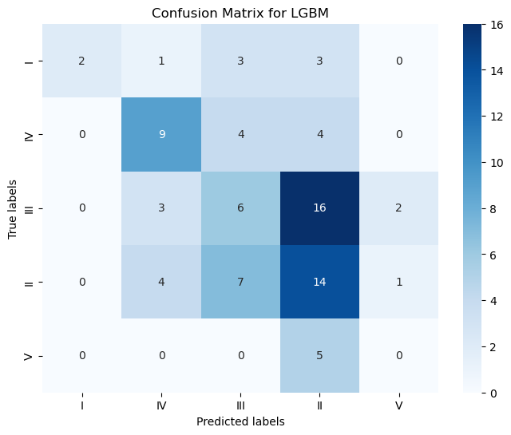

```python
mLgb = LGBMClassifier(objective='multiclass', verbose=0)
mLgb.fit(X_train, y_train)
mLgb_score=get_metrics_score(mLgb)
y_pred=mLgb.predict(X_test)
plot_confusion_matrix(y_test, y_pred, title='Confusion Matrix for LGBM')
```

```python
# defining list of models
models = [dTree,logreg,SVM_Classifier,rf_estimator,abc,gbclf, mLgb, mCat]

# defining empty lists to add train and test results
acc_train = []
acc_test = []
recall_train = []
recall_test = []
precision_train = []
precision_test = []
f1_train = []
f1_test = []

# looping through all the models to get the accuracy, precall and precision scores
for model in models:
    j = get_metrics_score(model,False)
    acc_train.append(np.round(j[0],2))
    acc_test.append(np.round(j[1],2))
    recall_train.append(np.round(j[2],2))
    recall_test.append(np.round(j[3],2))
    precision_train.append(np.round(j[4],2))
    precision_test.append(np.round(j[5],2))
    f1_train.append(np.round(j[6],2))
    f1_test.append(np.round(j[7],2))
```

```python
comparison_frame = pd.DataFrame({
    'Model': [
        'DecisionTree', 'Logistic Regression', 'SVM', 'Random Forest',
        'AdaBoost Classifier', 'GradientBoost Classifier', 'LightGBM', 'CatBoost'
    ],
    'Train_Accuracy': acc_train,
    'Test_Accuracy': acc_test,
    'Train_Recall': recall_train,
    'Test_Recall': recall_test,
    'Train_Precision': precision_train,
    'Test_Precision': precision_test,
    'Train_F1': f1_train,
    'Test_F1': f1_test
})

comparison_frame
```

|  | Model | Train_Accuracy | Test_Accuracy | Train_Recall | Test_Recall | Train_Precision | Test_Precision | Train_F1 | Test_F1 |
| --- | --- | --- | --- | --- | --- | --- | --- | --- | --- |
| 0 | DecisionTree | 1.0000000 | 0.4300000 | 1.0000000 | 0.4300000 | 1.0000000 | 0.4300000 | 1.0000000 | 0.4300000 |
| 1 | Logistic Regression | 0.7700000 | 0.4300000 | 0.7700000 | 0.4300000 | 0.7700000 | 0.4300000 | 0.7700000 | 0.4300000 |
| 2 | SVM | 0.9800000 | 0.3900000 | 0.9800000 | 0.3900000 | 0.9800000 | 0.3900000 | 0.9800000 | 0.3900000 |
| 3 | Random Forest | 1.0000000 | 0.4900000 | 1.0000000 | 0.4900000 | 1.0000000 | 0.4900000 | 1.0000000 | 0.4900000 |
| 4 | AdaBoost Classifier | 0.4600000 | 0.2900000 | 0.4600000 | 0.2900000 | 0.4600000 | 0.2900000 | 0.4600000 | 0.2900000 |
| 5 | GradientBoost Classifier | 1.0000000 | 0.4600000 | 1.0000000 | 0.4600000 | 1.0000000 | 0.4600000 | 1.0000000 | 0.4600000 |
| 6 | LightGBM | 1.0000000 | 0.3700000 | 1.0000000 | 0.3700000 | 1.0000000 | 0.3700000 | 1.0000000 | 0.3700000 |
| 7 | CatBoost | 1.0000000 | 0.4800000 | 1.0000000 | 0.4800000 | 1.0000000 | 0.4800000 | 1.0000000 | 0.4800000 |

[figure not shown]

```python
y_pred = model.predict(X_test)
from sklearn.metrics import confusion_matrix
import seaborn as sns
import matplotlib.pyplot as plt

# Compute confusion matrix
conf_matrix_catboost = confusion_matrix(y_test, y_pred)

# Visualize the confusion matrix
plt.figure(figsize=(8, 6))
sns.heatmap(conf_matrix_catboost, annot=True, fmt='g', cmap='Blues')
plt.xlabel('Predicted labels')
plt.ylabel('True labels')
plt.title('Confusion Matrix for DecisionTree Classifier')
plt.show()
```

# Further Steps

1. Tune the models. - Anzar
2. Create charts/plots - Biswa

## Hyperparameter Tuning

We will use Optuna to do hyperparameter tuning as it is fast and more efficient.

-- We will need to install optuna package

Please note, we will get varied results for each set of trials, we will stick with the best parameters

```python
import optuna
```

```python
## Running Optuna for Catboost

def objective(trial):
    params = {
        'iterations': trial.suggest_int('iterations', 50, 1500),
        'learning_rate': trial.suggest_loguniform('learning_rate', 1e-3, 1e-1),
        'task_type': 'CPU',
        'verbose': False
    }

    # Train the CatBoost classifier
    model = CatBoostClassifier(**params)
    #model = CatBoostClassifier(task_type='CPU', iterations=58, learning_rate=0.08014302384906728)

    model.fit(X_train, y_train, eval_set=(X_test, y_test), early_stopping_rounds=50, verbose=False)

    # Predict on the test set
    y_pred = model.predict(X_test)

    # Calculate accuracy
    accuracy = accuracy_score(y_test, y_pred)

    return accuracy

# Create a study object and optimize hyperparameters
study_catboost = optuna.create_study(direction='maximize')
study_catboost.optimize(objective, n_trials=20)

# Print the best hyperparameters found
best_params_catboost = study_catboost.best_params
best_value_catboost = study_catboost.best_value
print(f"Best accuracy: {best_value_catboost:.4f}")
print("Best parameters:")
for param, value in best_params_catboost.items():
    print(f"\t{param}: {value}")
```

```
[I 2024-03-11 00:13:59,851] A new study created in memory with name: no-name-8278a179-387f-4edf-9fe4-43ec9a94a20a
[I 2024-03-11 00:14:16,849] Trial 0 finished with value: 0.4166666666666667 and parameters: {'iterations': 572, 'learning_rate': 0.013176442146966115}. Best is trial 0 with value: 0.4166666666666667.
[I 2024-03-11 00:14:29,792] Trial 1 finished with value: 0.30952380952380953 and parameters: {'iterations': 439, 'learning_rate': 0.0016747076617236228}. Best is trial 0 with value: 0.4166666666666667.
[I 2024-03-11 00:14:48,806] Trial 2 finished with value: 0.3333333333333333 and parameters: {'iterations': 654, 'learning_rate': 0.0037776327194423177}. Best is trial 0 with value: 0.4166666666666667.
[I 2024-03-11 00:15:07,916] Trial 3 finished with value: 0.4642857142857143 and parameters: {'iterations': 1405, 'learning_rate': 0.019691452679607334}. Best is trial 3 with value: 0.4642857142857143.
[I 2024-03-11 00:15:39,688] Trial 4 finished with value: 0.35714285714285715 and parameters: {'iterations': 1088, 'learning_rate': 0.0036854516317089076}. Best is trial 3 with value: 0.4642857142857143.
[I 2024-03-11 00:15:54,940] Trial 5 finished with value: 0.4642857142857143 and parameters: {'iterations': 1289, 'learning_rate': 0.04238214212185156}. Best is trial 3 with value: 0.4642857142857143.
[I 2024-03-11 00:16:09,740] Trial 6 finished with value: 0.44047619047619047 and parameters: {'iterations': 464, 'learning_rate': 0.04513646661248738}. Best is trial 3 with value: 0.4642857142857143.
[I 2024-03-11 00:16:28,951] Trial 7 finished with value: 0.5 and parameters: {'iterations': 1083, 'learning_rate': 0.051998133550872155}. Best is trial 7 with value: 0.5.
[I 2024-03-11 00:16:39,190] Trial 8 finished with value: 0.30952380952380953 and parameters: {'iterations': 345, 'learning_rate': 0.006698723718311011}. Best is trial 7 with value: 0.5.
[I 2024-03-11 00:16:54,517] Trial 9 finished with value: 0.4642857142857143 and parameters: {'iterations': 833, 'learning_rate': 0.07920681027635669}. Best is trial 7 with value: 0.5.
[I 2024-03-11 00:16:57,093] Trial 10 finished with value: 0.36904761904761907 and parameters: {'iterations': 70, 'learning_rate': 0.0987541497100959}. Best is trial 7 with value: 0.5.
[I 2024-03-11 00:17:29,476] Trial 11 finished with value: 0.47619047619047616 and parameters: {'iterations': 1485, 'learning_rate': 0.018658338104002307}. Best is trial 7 with value: 0.5.
[I 2024-03-11 00:17:56,286] Trial 12 finished with value: 0.4523809523809524 and parameters: {'iterations': 1068, 'learning_rate': 0.027621600284916868}. Best is trial 7 with value: 0.5.
[I 2024-03-11 00:18:29,522] Trial 13 finished with value: 0.44047619047619047 and parameters: {'iterations': 1143, 'learning_rate': 0.01004572505418466}. Best is trial 7 with value: 0.5.
[I 2024-03-11 00:18:50,583] Trial 14 finished with value: 0.5119047619047619 and parameters: {'iterations': 1476, 'learning_rate': 0.037635138771591324}. Best is trial 14 with value: 0.5119047619047619.
[I 2024-03-11 00:19:14,145] Trial 15 finished with value: 0.4642857142857143 and parameters: {'iterations': 941, 'learning_rate': 0.050147118532045405}. Best is trial 14 with value: 0.5119047619047619.
[I 2024-03-11 00:19:41,007] Trial 16 finished with value: 0.47619047619047616 and parameters: {'iterations': 1310, 'learning_rate': 0.03193429123560866}. Best is trial 14 with value: 0.5119047619047619.
[I 2024-03-11 00:19:54,859] Trial 17 finished with value: 0.4523809523809524 and parameters: {'iterations': 1238, 'learning_rate': 0.055877832544427346}. Best is trial 14 with value: 0.5119047619047619.
[I 2024-03-11 00:20:21,871] Trial 18 finished with value: 0.42857142857142855 and parameters: {'iterations': 925, 'learning_rate': 0.022372659931237247}. Best is trial 14 with value: 0.5119047619047619.
[I 2024-03-11 00:20:40,727] Trial 19 finished with value: 0.4642857142857143 and parameters: {'iterations': 1497, 'learning_rate': 0.0760551271697069}. Best is trial 14 with value: 0.5119047619047619.
```

```
Best accuracy: 0.5119
Best parameters:
	iterations: 1476
	learning_rate: 0.037635138771591324
```

```python
## Optuna with RF

def objective(trial):
    params = {
        'n_estimators': trial.suggest_int('n_estimators', 10, 2500),
        'min_samples_split': trial.suggest_int('min_samples_split', 2, 20),
        'min_samples_leaf': trial.suggest_int('min_samples_leaf', 1, 20),
    }

    # Train the RandomForest classifier
    model = RandomForestClassifier(**params)
    model.fit(X_train, y_train)

    # Predict on the test set
    y_pred = model.predict(X_test)

    # Calculate accuracy
    accuracy = accuracy_score(y_test, y_pred)

    return accuracy

# Create a study object and optimize hyperparameters
study_rf = optuna.create_study(direction='maximize')
study_rf.optimize(objective, n_trials=20)

# Print the best hyperparameters found
best_params_rf = study_rf.best_params
best_value_rf = study_rf.best_value
print(f"Best accuracy: {best_value_rf:.4f}")
print("Best parameters:")
for param, value in best_params_rf.items():
    print(f"\t{param}: {value}")
```

```
[I 2024-03-11 00:24:57,416] A new study created in memory with name: no-name-99c20611-f2cb-4700-b392-61f0824b86ac
[I 2024-03-11 00:25:00,671] Trial 0 finished with value: 0.30952380952380953 and parameters: {'n_estimators': 1558, 'min_samples_split': 14, 'min_samples_leaf': 12}. Best is trial 0 with value: 0.30952380952380953.
[I 2024-03-11 00:25:01,094] Trial 1 finished with value: 0.3333333333333333 and parameters: {'n_estimators': 193, 'min_samples_split': 3, 'min_samples_leaf': 9}. Best is trial 1 with value: 0.3333333333333333.
[I 2024-03-11 00:25:04,243] Trial 2 finished with value: 0.30952380952380953 and parameters: {'n_estimators': 1591, 'min_samples_split': 10, 'min_samples_leaf': 13}. Best is trial 1 with value: 0.3333333333333333.
[I 2024-03-11 00:25:09,398] Trial 3 finished with value: 0.39285714285714285 and parameters: {'n_estimators': 1800, 'min_samples_split': 3, 'min_samples_leaf': 5}. Best is trial 3 with value: 0.39285714285714285.
[I 2024-03-11 00:25:10,656] Trial 4 finished with value: 0.38095238095238093 and parameters: {'n_estimators': 478, 'min_samples_split': 8, 'min_samples_leaf': 6}. Best is trial 3 with value: 0.39285714285714285.
[I 2024-03-11 00:25:12,661] Trial 5 finished with value: 0.30952380952380953 and parameters: {'n_estimators': 1055, 'min_samples_split': 10, 'min_samples_leaf': 18}. Best is trial 3 with value: 0.39285714285714285.
[I 2024-03-11 00:25:13,747] Trial 6 finished with value: 0.30952380952380953 and parameters: {'n_estimators': 561, 'min_samples_split': 15, 'min_samples_leaf': 16}. Best is trial 3 with value: 0.39285714285714285.
[I 2024-03-11 00:25:18,175] Trial 7 finished with value: 0.30952380952380953 and parameters: {'n_estimators': 2171, 'min_samples_split': 11, 'min_samples_leaf': 14}. Best is trial 3 with value: 0.39285714285714285.
[I 2024-03-11 00:25:22,662] Trial 8 finished with value: 0.3333333333333333 and parameters: {'n_estimators': 1966, 'min_samples_split': 12, 'min_samples_leaf': 10}. Best is trial 3 with value: 0.39285714285714285.
[I 2024-03-11 00:25:23,785] Trial 9 finished with value: 0.32142857142857145 and parameters: {'n_estimators': 526, 'min_samples_split': 7, 'min_samples_leaf': 11}. Best is trial 3 with value: 0.39285714285714285.
[I 2024-03-11 00:25:33,920] Trial 10 finished with value: 0.4523809523809524 and parameters: {'n_estimators': 2452, 'min_samples_split': 20, 'min_samples_leaf': 1}. Best is trial 10 with value: 0.4523809523809524.
[I 2024-03-11 00:25:43,940] Trial 11 finished with value: 0.4523809523809524 and parameters: {'n_estimators': 2442, 'min_samples_split': 20, 'min_samples_leaf': 1}. Best is trial 10 with value: 0.4523809523809524.
[I 2024-03-11 00:25:54,558] Trial 12 finished with value: 0.44047619047619047 and parameters: {'n_estimators': 2435, 'min_samples_split': 20, 'min_samples_leaf': 1}. Best is trial 10 with value: 0.4523809523809524.
[I 2024-03-11 00:26:04,764] Trial 13 finished with value: 0.4642857142857143 and parameters: {'n_estimators': 2496, 'min_samples_split': 20, 'min_samples_leaf': 1}. Best is trial 13 with value: 0.4642857142857143.
[I 2024-03-11 00:26:08,003] Trial 14 finished with value: 0.42857142857142855 and parameters: {'n_estimators': 1146, 'min_samples_split': 17, 'min_samples_leaf': 4}. Best is trial 13 with value: 0.4642857142857143.
[I 2024-03-11 00:26:14,938] Trial 15 finished with value: 0.44047619047619047 and parameters: {'n_estimators': 2203, 'min_samples_split': 17, 'min_samples_leaf': 3}. Best is trial 13 with value: 0.4642857142857143.
[I 2024-03-11 00:26:25,420] Trial 16 finished with value: 0.38095238095238093 and parameters: {'n_estimators': 2499, 'min_samples_split': 17, 'min_samples_leaf': 7}. Best is trial 13 with value: 0.4642857142857143.
[I 2024-03-11 00:26:30,810] Trial 17 finished with value: 0.32142857142857145 and parameters: {'n_estimators': 2000, 'min_samples_split': 20, 'min_samples_leaf': 8}. Best is trial 13 with value: 0.4642857142857143.
[I 2024-03-11 00:26:37,386] Trial 18 finished with value: 0.42857142857142855 and parameters: {'n_estimators': 1638, 'min_samples_split': 18, 'min_samples_leaf': 3}. Best is trial 13 with value: 0.4642857142857143.
[I 2024-03-11 00:26:40,042] Trial 19 finished with value: 0.30952380952380953 and parameters: {'n_estimators': 1374, 'min_samples_split': 14, 'min_samples_leaf': 20}. Best is trial 13 with value: 0.4642857142857143.
```

```
Best accuracy: 0.4643
Best parameters:
	n_estimators: 2496
	min_samples_split: 20
	min_samples_leaf: 1
```

```python
mCat_tuned = CatBoostClassifier(**best_params_catboost, verbose=0, task_type = 'CPU')

mCat_tuned.fit(X_train, y_train)

mCat_tuned_score=get_metrics_score(mCat_tuned)

rf_tuned = RandomForestClassifier(**best_params_rf)

rf_tuned.fit(X_train, y_train)

rf_tuned_score=get_metrics_score(rf_tuned)
```

```
Accuracy on training set :  1.0
Accuracy on test set :  0.5
Recall on training set :  1.0
Recall on test set :  0.5
Precision on training set :  1.0
Precision on test set :  0.5
f1 on training set :  1.0
f1 on test set :  0.5
Accuracy on training set :  0.9940119760479041
Accuracy on test set :  0.44047619047619047
Recall on training set :  0.9940119760479041
Recall on test set :  0.44047619047619047
Precision on training set :  0.9940119760479041
Precision on test set :  0.44047619047619047
f1 on training set :  0.9940119760479041
f1 on test set :  0.44047619047619047
```

```python
# defining list of models
models = [dTree,logreg,SVM_Classifier,rf_estimator,abc,gbclf, mLgb, mCat, mCat_tuned, rf_tuned]

# defining empty lists to add train and test results
acc_train = []
acc_test = []
recall_train = []
recall_test = []
precision_train = []
precision_test = []
f1_train = []
f1_test = []

# looping through all the models to get the accuracy, precall and precision scores
for model in models:
    j = get_metrics_score(model,False)
    acc_train.append(np.round(j[0],2))
    acc_test.append(np.round(j[1],2))
    recall_train.append(np.round(j[2],2))
    recall_test.append(np.round(j[3],2))
    precision_train.append(np.round(j[4],2))
    precision_test.append(np.round(j[5],2))
    f1_train.append(np.round(j[6],2))
    f1_test.append(np.round(j[7],2))
```

```python
comparison_frame = pd.DataFrame({'Model':['DecisionTree','Logistic Regression',
                                        'SVM','Random Forest','AdaBoost Classifier','GradientBoost Classifer',
                                          'LGBM', 'Catboost', 'CatBoost Tuned', 'RandomForest Tuned'],
                                          'Train_Accuracy': acc_train,'Test_Accuracy': acc_test,
                                          'Train_Recall':recall_train,'Test_Recall':recall_test,
                                          'Train_Precision':precision_train,'Test_Precision':precision_test,
                                          'Train_F1':f1_train,'Test_F1':f1_test})
comparison_frame
```

|  | Model | Train_Accuracy | Test_Accuracy | Train_Recall | Test_Recall | Train_Precision | Test_Precision | Train_F1 | Test_F1 |
| --- | --- | --- | --- | --- | --- | --- | --- | --- | --- |
| 0 | DecisionTree | 1.0000000 | 0.4300000 | 1.0000000 | 0.4300000 | 1.0000000 | 0.4300000 | 1.0000000 | 0.4300000 |
| 1 | Logistic Regression | 0.7700000 | 0.4300000 | 0.7700000 | 0.4300000 | 0.7700000 | 0.4300000 | 0.7700000 | 0.4300000 |
| 2 | SVM | 0.9800000 | 0.3900000 | 0.9800000 | 0.3900000 | 0.9800000 | 0.3900000 | 0.9800000 | 0.3900000 |
| 3 | Random Forest | 1.0000000 | 0.4900000 | 1.0000000 | 0.4900000 | 1.0000000 | 0.4900000 | 1.0000000 | 0.4900000 |
| 4 | AdaBoost Classifier | 0.4600000 | 0.2900000 | 0.4600000 | 0.2900000 | 0.4600000 | 0.2900000 | 0.4600000 | 0.2900000 |
| 5 | GradientBoost Classifer | 1.0000000 | 0.4600000 | 1.0000000 | 0.4600000 | 1.0000000 | 0.4600000 | 1.0000000 | 0.4600000 |
| 6 | LGBM | 1.0000000 | 0.3700000 | 1.0000000 | 0.3700000 | 1.0000000 | 0.3700000 | 1.0000000 | 0.3700000 |
| 7 | Catboost | 1.0000000 | 0.4800000 | 1.0000000 | 0.4800000 | 1.0000000 | 0.4800000 | 1.0000000 | 0.4800000 |
| 8 | CatBoost Tuned | 1.0000000 | 0.5000000 | 1.0000000 | 0.5000000 | 1.0000000 | 0.5000000 | 1.0000000 | 0.5000000 |
| 9 | RandomForest Tuned | 0.9900000 | 0.4400000 | 0.9900000 | 0.4400000 | 0.9900000 | 0.4400000 | 0.9900000 | 0.4400000 |

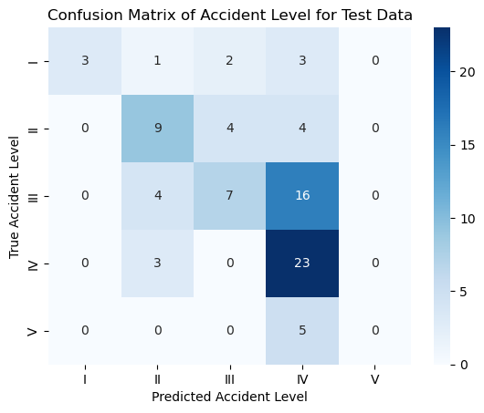

```python
# Confusion Matrix for Test data

pred_labels = mCat_tuned.predict(X_test)

conf_matrix = confusion_matrix(y_test, pred_labels)

labels = ['I', 'II', 'III', 'IV', 'V']

sns.heatmap(conf_matrix, annot=True, fmt='d', cmap='Blues', xticklabels=labels, yticklabels=labels)

plt.xlabel('Predicted Accident Level')
plt.ylabel('True Accident Level')
plt.title('Confusion Matrix of Accident Level for Test Data')

plt.show()
```

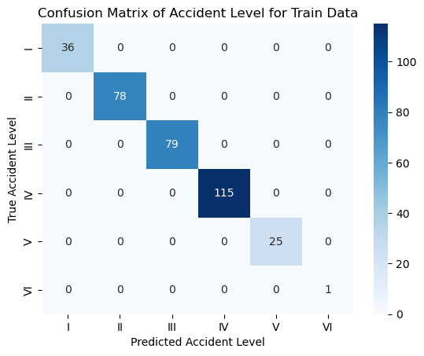

```python
# Confusion Matrix for Train Data

pred_labels_train = mCat_tuned.predict(X_train)

conf_matrix = confusion_matrix(y_train, pred_labels_train)

labels = ['I', 'II', 'III', 'IV', 'V', 'VI']

sns.heatmap(conf_matrix, annot=True, fmt='d', cmap='Blues', xticklabels=labels, yticklabels=labels)

plt.xlabel('Predicted Accident Level')
plt.ylabel('True Accident Level')
plt.title('Confusion Matrix of Accident Level for Train Data')

plt.show()
```